# Industrial Robots Overview

# Summary

Industrial robots are creating smart and innovative factories. They are used extensively in manufacturing to perform repetitive tasks such as assembly and welding, and typically operate inside cages or fences to protect operators against injury. Safety cages have been the traditional approach to safeguarding humans from industrial robots, however this practice has its drawbacks:

1. Safety cages take up space and limit manufacturer’s ability to add more robots on the factory floor
2. Stopping the robot every time a human enters the safety cage leads to increased cycle times (time for robot to complete one operation), thereby reducing manufacturing productivity

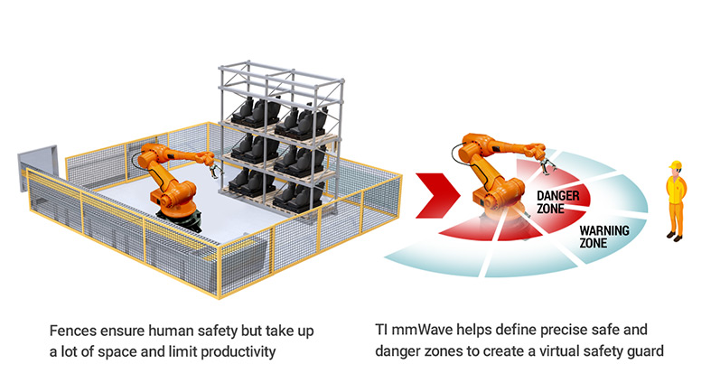

Customers are using TI mmWave based area scanners for **Industrial robot safeguarding** to **improve manufacturing productivity** without compromising **operator safety**.

# TI’s Offering

What can TI’s IWR6843 / IWR6843AOP mmWave radar sensors offer for Industrial Robot Safeguarding?

1. **Define precise warning and keep out zones** around the robot to create a **virtual safety guard**, eliminating the need for safety cages
2. Enable **accurate measurement of distance plus relative velocities** of objects allowing robot to take more predictive action, such as stopping based on speed of approach
3. **Integrated tracking algorithms** help improve productivity by **avoiding stops due to false triggers** if operator is moving away from the machine
4. **Immunity to environmental factors** such as debris, sparks, smoke and lighting conditions on factory floors offers **increased reliability over LiDAR and cameras** in similar conditions
5. **IEC 61508 SIL 2 certification** and supporting Functional Safety collateral help streamline system safety certification for faster time to market

# Getting Started

Get started today with mmWave for Industrial Robot Safeguarding!

## Featured Demonstration Videos:

[**Industrial Robot Safeguarding using TI mmWave**](https://training.ti.com/industrial-robot-safeguarding-demo-using-ti-mmwave)

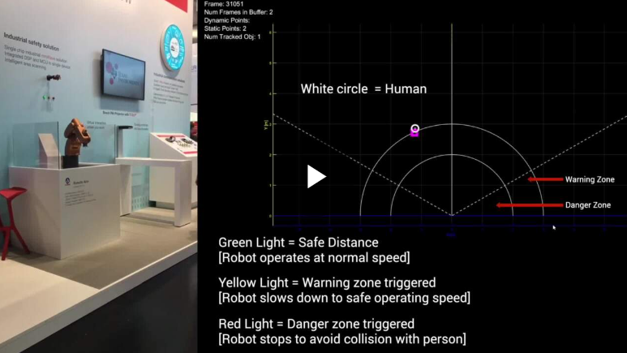

[**Area Scanners with 60GHz TI mmWave sensors**](https://training.ti.com/area-scanners-60ghz-mmwave-sensors)

[video not shown]

[**AI-enabled, faster and safer industrial robots and cobots demo**](https://training.ti.com/ai-enabled-faster-and-safer-industrial-robots-and-cobots-demo)

[video not shown]

## Development Resources

- Area Scanner Lab with static object detection
- [mmWave diagnostic and monitoring reference design for Functional Safety](https://www.ti.com/tool/TIDEP-01025)

## Certification

- [TI mmWave Radar Device Regulatory Compliance Guide](http://www.ti.com/lit/spracp3)
- TI mmWave Certification Database

## Recommend Devices

- IWR6843 - 4Rx3Tx 60GHz mmWave radar sensor w/ DSP & HWA (production)
  - Check out the IWR6843ISK evaluation module to get started
- IWR6843AOP – IWR6843 with integrated antenna on the package (production)
  - Check out the IWR6843AOPEVM evaluation module to get started

## Functional Safety Resources

- [Understanding Functional Safety in Automotive and Industrial Applications](https://e2e.ti.com/blogs_/b/process/posts/understanding-the-importance-of-functional-safety-in-automotive-and-industrial-sensing-applications)
- [TI mmWave Functional Safety Enablers](http://www.ti.com/lit/sprt747)

# Third Party Resources

- [Designing TI mmWave radar made easier using our third-party ecosystem](https://e2e.ti.com/blogs_/b/industrial_strength/posts/ti-mmwave-radar-made-easy-with-our-third-party-ecosystem)
- [Browse third-party solutions and find the right third-party to meet your needs](https://www.ti.com/tool/MMWAVE-3P-SEARCH)

Video Topic

Preview

[**INXPECT**](https://www.inxpect.com/en/)

[**Virtual Safety Guard Demo for Industrial Robots with TI mmWave**](https://training.ti.com/virtual-safety-guard-demo-industrial-robots-using-ti-mmwave)

[video not shown]

[**INXPECT**](https://www.inxpect.com/en/)

[**TI mmWave enabling high resolution safe radars for robotics with INXPECT**](https://training.ti.com/ti-mmwave-enabling-high-resolution-safe-radars-robotics-inxpect)

[video not shown]

# Need more information?

- Visit the Industrial mmWave Radar Sensor portal at [ti.com/iwr](https://www.ti.com/sensors/mmwave-radar/industrial/overview.html)
- Search for your question or post a new question on the [mmWave E2E forum](https://e2e.ti.com/support/sensor/mmwave_sensors/f/1023)